# Starbucks Capstone Challenge

### Introduction

This data set contains simulated data that mimics customer behavior on the Starbucks rewards mobile app. Once every few days, Starbucks sends out an offer to users of the mobile app. An offer can be merely an advertisement for a drink or an actual offer such as a discount or BOGO (buy one get one free). Some users might not receive any offer during certain weeks.

Not all users receive the same offer, and that is the challenge to solve with this data set.

Your task is to combine transaction, demographic and offer data to determine which demographic groups respond best to which offer type. This data set is a simplified version of the real Starbucks app because the underlying simulator only has one product whereas Starbucks actually sells dozens of products.

Every offer has a validity period before the offer expires. As an example, a BOGO offer might be valid for only 5 days. You'll see in the data set that informational offers have a validity period even though these ads are merely providing information about a product; for example, if an informational offer has 7 days of validity, you can assume the customer is feeling the influence of the offer for 7 days after receiving the advertisement.

You'll be given transactional data showing user purchases made on the app including the timestamp of purchase and the amount of money spent on a purchase. This transactional data also has a record for each offer that a user receives as well as a record for when a user actually views the offer. There are also records for when a user completes an offer.

Keep in mind as well that someone using the app might make a purchase through the app without having received an offer or seen an offer.

### Example

To give an example, a user could receive a discount offer buy 10 dollars get 2 off on Monday. The offer is valid for 10 days from receipt. If the customer accumulates at least 10 dollars in purchases during the validity period, the customer completes the offer.

However, there are a few things to watch out for in this data set. Customers do not opt into the offers that they receive; in other words, a user can receive an offer, never actually view the offer, and still complete the offer. For example, a user might receive the "buy 10 dollars get 2 dollars off offer", but the user never opens the offer during the 10 day validity period. The customer spends 15 dollars during those ten days. There will be an offer completion record in the data set; however, the customer was not influenced by the offer because the customer never viewed the offer.

### Cleaning

This makes data cleaning especially important and tricky.

You'll also want to take into account that some demographic groups will make purchases even if they don't receive an offer. From a business perspective, if a customer is going to make a 10 dollar purchase without an offer anyway, you wouldn't want to send a buy 10 dollars get 2 dollars off offer. You'll want to try to assess what a certain demographic group will buy when not receiving any offers.

### Final Advice

Because this is a capstone project, you are free to analyze the data any way you see fit. For example, you could build a machine learning model that predicts how much someone will spend based on demographics and offer type. Or you could build a model that predicts whether or not someone will respond to an offer. Or, you don't need to build a machine learning model at all. You could develop a set of heuristics that determine what offer you should send to each customer (i.e., 75 percent of women customers who were 35 years old responded to offer A vs 40 percent from the same demographic to offer B, so send offer A).

# Data Sets

The data is contained in three files:

- portfolio.json - containing offer ids and meta data about each offer (duration, type, etc.)
- profile.json - demographic data for each customer
- transcript.json - records for transactions, offers received, offers viewed, and offers completed

Here is the schema and explanation of each variable in the files:

**portfolio.json**

- id (string) - offer id
- offer_type (string) - type of offer ie BOGO, discount, informational
- difficulty (int) - minimum required spend to complete an offer
- reward (int) - reward given for completing an offer
- duration (int) - time for offer to be open, in days
- channels (list of strings)

**profile.json**

- age (int) - age of the customer
- became_member_on (int) - date when customer created an app account
- gender (str) - gender of the customer (note some entries contain 'O' for other rather than M or F)
- id (str) - customer id
- income (float) - customer's income

**transcript.json**

- event (str) - record description (ie transaction, offer received, offer viewed, etc.)
- person (str) - customer id
- time (int) - time in hours since start of test. The data begins at time t=0
- value - (dict of strings) - either an offer id or transaction amount depending on the record

**Note:** If you are using the workspace, you will need to go to the terminal and run the command `conda update pandas` before reading in the files. This is because the version of pandas in the workspace cannot read in the transcript.json file correctly, but the newest version of pandas can. You can access the termnal from the orange icon in the top left of this notebook.

You can see how to access the terminal and how the install works using the two images below. First you need to access the terminal:

[figure not shown]

Then you will want to run the above command:

[figure not shown]

Finally, when you enter back into the notebook (use the jupyter icon again), you should be able to run the below cell without any errors.

```python
# Import the librararies in Python required for this project
import pandas as pd
import numpy as np
import seaborn as sns
import math
import json
import datetime
import matplotlib.pyplot as plt

from sklearn.preprocessing import MinMaxScaler
from sklearn.model_selection import train_test_split, GridSearchCV
from sklearn.svm import SVC
from sklearn.tree import DecisionTreeClassifier
from sklearn.naive_bayes import GaussianNB
from sklearn.neighbors import KNeighborsClassifier
from sklearn.linear_model import LogisticRegression
from sklearn.ensemble import RandomForestRegressor

%matplotlib inline
```

```python
# 1.READ THE DATA AND CLEANING- PORTFOLIO.JSON
```

```python
#Read portfolio.json
portfolio = pd.read_json('data/portfolio.json', orient='records', lines=True)
```

```python
# See the top 10 rows of portfolio.json
portfolio.head(10)
```

|  | channels | difficulty | duration | id | offer_type | reward |
| --- | --- | --- | --- | --- | --- | --- |
| 0 | [email, mobile, social] | 10 | 7 | ae264e3637204a6fb9bb56bc8210ddfd | bogo | 10 |
| 1 | [web, email, mobile, social] | 10 | 5 | 4d5c57ea9a6940dd891ad53e9dbe8da0 | bogo | 10 |
| 2 | [web, email, mobile] | 0 | 4 | 3f207df678b143eea3cee63160fa8bed | informational | 0 |
| 3 | [web, email, mobile] | 5 | 7 | 9b98b8c7a33c4b65b9aebfe6a799e6d9 | bogo | 5 |
| 4 | [web, email] | 20 | 10 | 0b1e1539f2cc45b7b9fa7c272da2e1d7 | discount | 5 |
| 5 | [web, email, mobile, social] | 7 | 7 | 2298d6c36e964ae4a3e7e9706d1fb8c2 | discount | 3 |
| 6 | [web, email, mobile, social] | 10 | 10 | fafdcd668e3743c1bb461111dcafc2a4 | discount | 2 |
| 7 | [email, mobile, social] | 0 | 3 | 5a8bc65990b245e5a138643cd4eb9837 | informational | 0 |
| 8 | [web, email, mobile, social] | 5 | 5 | f19421c1d4aa40978ebb69ca19b0e20d | bogo | 5 |
| 9 | [web, email, mobile] | 10 | 7 | 2906b810c7d4411798c6938adc9daaa5 | discount | 2 |

```python
# See Columns details of  the portfolio.json
portfolio.info()
```

```
<class 'pandas.core.frame.DataFrame'>
RangeIndex: 10 entries, 0 to 9
Data columns (total 6 columns):
channels      10 non-null object
difficulty    10 non-null int64
duration      10 non-null int64
id            10 non-null object
offer_type    10 non-null object
reward        10 non-null int64
dtypes: int64(3), object(3)
memory usage: 560.0+ bytes
```

```python
# see the total rows and columns of portfolio.json
portfolio.shape
```

```
(10, 6)
```

```python
# See the missing values portfolio.json
portfolio.isna().sum()
```

```
channels      0
difficulty    0
duration      0
id            0
offer_type    0
reward        0
dtype: int64
```

```python
#See the offers in portfolio.json
portfolio['offer_type'].unique()
```

```
array(['bogo', 'informational', 'discount'], dtype=object)
```

```python
#See the duplicates in portfolio.json
portfolio.columns.duplicated().sum()
```

```
0
```

```python
# See the unique offers from portfolio.json
portfolio['id'].nunique()
```

```
10
```

```python
# Let us group offer_type
portfolio.groupby('offer_type')['id'].count()
```

```
offer_type
bogo             4
discount         4
informational    2
Name: id, dtype: int64
```

```python
#Summary of Portfolio datasetfrom above results:
#Portfolio dataset has 6 columns and 10 rows.
#It has no null values nor duplicates.
#There are three types of offers : 'bogo'(Buy One Get One free), 'informational' and 'discount'.
#Bogo - 4 offers, disount-4 offers, informational-2 offers
#The unit of The 'difficulty' column is dollars
#But we can  not say how difficult to be rewarded.
#Rescaling this info is a good and to be done before Modeling.
```

```python
# 1.READ THE DATA AND CLEANING- PROFILE.JSON
```

```python
# read from portfolio.json dataset
profile = pd.read_json('data/profile.json', orient='records', lines=True)
```

```python
# see contents of the dataset of profile.json .
profile.head()
```

|  | age | became_member_on | gender | id | income |
| --- | --- | --- | --- | --- | --- |
| 0 | 118 | 20170212 | None | 68be06ca386d4c31939f3a4f0e3dd783 | NaN |
| 1 | 55 | 20170715 | F | 0610b486422d4921ae7d2bf64640c50b | 112000.0 |
| 2 | 118 | 20180712 | None | 38fe809add3b4fcf9315a9694bb96ff5 | NaN |
| 3 | 75 | 20170509 | F | 78afa995795e4d85b5d9ceeca43f5fef | 100000.0 |
| 4 | 118 | 20170804 | None | a03223e636434f42ac4c3df47e8bac43 | NaN |

```python
# see the column details of the profile.json
profile.info()
```

```
<class 'pandas.core.frame.DataFrame'>
RangeIndex: 17000 entries, 0 to 16999
Data columns (total 5 columns):
age                 17000 non-null int64
became_member_on    17000 non-null int64
gender              14825 non-null object
id                  17000 non-null object
income              14825 non-null float64
dtypes: float64(1), int64(2), object(2)
memory usage: 664.1+ KB
```

```python
# see the rows and columns of profile.json
profile.shape
```

```
(17000, 5)
```

```python
# See the missing values profile.json
profile.isna().sum()
```

```
age                    0
became_member_on       0
gender              2175
id                     0
income              2175
dtype: int64
```

```python
#See the duplicates in profile.json
profile.columns.duplicated().sum()
```

```
0
```

```python
#See the unique customers in  profile.json
profile['id'].nunique()
```

```
17000
```

```python
# Let us check the column-difficulty uniqueness
difficulty_unique = np.sort(portfolio.difficulty.unique())
difficulty_unique
```

```
array([ 0,  5,  7, 10, 20])
```

```python
#See the unique values of the column-gender in  profile.json
profile['gender'].unique()
```

```
array([None, 'F', 'M', 'O'], dtype=object)
```

```python
# See the data where tha age is mentioned as 118 , the missing age
profile[profile['age']==118].count()
```

```
age                 2175
became_member_on    2175
gender                 0
id                  2175
income                 0
dtype: int64
```

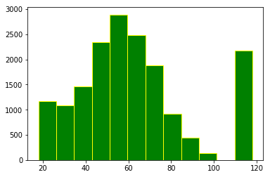

```python
# plot a graph of distribution of age groups
plt.hist(profile['age'], edgecolor="yellow", color="green", bins=12);
```

```python
#To Check number customers based on gender
profile.gender.value_counts()
```

```
M    8484
F    6129
O     212
Name: gender, dtype: int64
```